# Homework Case Study: Phillips Curve Analysis for the U.S.

Author

Dr. Logan Kelly

**Assignment Overview: Steps to Complete**

1. Load necessary R packages.
2. Download U.S. Unemployment and CPI data from FRED.
3. Create a monthly Inflation series from the CPI.
4. Perform Exploratory Data Analysis (EDA):
   - Generate summary statistics.
   - Create time series plots.
5. Test for stationarity of unemployment and inflation using the Augmented Dickey-Fuller (ADF) test.
6. Difference series if necessary to achieve stationarity.
7. Estimate a basic Phillips Curve model: Inflation as a function of Unemployment.
8. Test for serial correlation in the residuals using the Breusch-Godfrey test (up to lag 12).
9. Improve the model by adding one lag of inflation.
10. Interpret the coefficients, especially lagged inflation, and discuss policy implications.
11. Bonus: Test for structural breaks using the Bai-Perron method.
12. Optional: Re-estimate the Phillips Curve before and after identified breakpoints.
13. Submit your R code, outputs, plots, and written answers.

# 1 Case Study: Exploring the Phillips Curve

This case study examines the relationship between U.S. unemployment and inflation, commonly known as the Phillips Curve. You will follow a structured analysis process to clean the data, explore the data visually, test statistical properties, estimate regression models, and interpret economic meaning based on the results.

# 2 Instructions

This section provides detailed steps to follow. Complete each part carefully, and answer the interpretation questions as you go.

# 3 1. Load Required Packages

We will use several R packages for data handling, statistical testing, and visualization.

```r
if (!require("pacman")) install.packages("pacman")
pacman::p_load(
  tidyverse,
  quantmod,
  urca,
  tseries,
  lmtest,
  zoo,
  lubridate,
  strucchange
)
```

**Explanation:**  
`pacman` simplifies loading multiple libraries at once.  
We will use packages for downloading data, stationarity testing, regression modeling, diagnostics, and structural break analysis.

# 4 2. Download the Data from FRED

We will analyze two monthly time series:

- **UNRATE**: Civilian Unemployment Rate
- **CPIAUCSL**: Consumer Price Index for All Urban Consumers

```r
# Download series
getSymbols("UNRATE", src = "FRED")
```

```
[1] "UNRATE"
```

```r
getSymbols("CPIAUCSL", src = "FRED")
```

```
[1] "CPIAUCSL"
```

**Explanation:**  
These series are sourced from the Federal Reserve Economic Data (FRED) database. They represent core U.S. macroeconomic indicators.

# 5 3. Create the Inflation Rate Series

We will compute monthly inflation as the percent change in CPI.

```r
# Compute monthly inflation rate
inflation <- 100 * diff(log(CPIAUCSL))

# Create inflation data frame
inflation_data <- data.frame(
  Date = index(inflation),
  coredata(inflation)
)
colnames(inflation_data) <- c("Date", "Inflation")

# Create unemployment data frame
unemployment_data <- data.frame(
  Date = index(UNRATE),
  coredata(UNRATE)
)
colnames(unemployment_data) <- c("Date", "Unemployment")

# Merge datasets by Date
phillips_data <- left_join(inflation_data, unemployment_data, by = "Date")

# Remove missing values
phillips_data <- drop_na(phillips_data)

# View merged data
head(phillips_data)
```

```
        Date   Inflation Unemployment
1 1948-01-01  1.14675285          3.4
2 1948-02-01 -0.04223865          3.8
3 1948-03-01 -0.72080024          4.0
4 1948-04-01  1.35251428          3.9
5 1948-05-01  0.79448463          3.5
6 1948-06-01  0.58139699          3.6
```

**Explanation:**  
This process carefully builds two clean data frames and merges them by date, ensuring that inflation and unemployment are properly aligned.

# 6 Exploratory Data Analysis (EDA)

EDA helps us understand trends, volatility, and potential issues before modeling.

## 6.1 4. Summarize and Plot the Data

```r
# Summary statistics
summary(phillips_data$Unemployment)
```

```
   Min. 1st Qu.  Median    Mean 3rd Qu.    Max.
  2.500   4.300   5.500   5.678   6.700  14.800
```

```r
summary(phillips_data$Inflation)
```

```
   Min. 1st Qu.  Median    Mean 3rd Qu.    Max.
-1.7864  0.1003  0.2454  0.2820  0.4341  1.7938
```

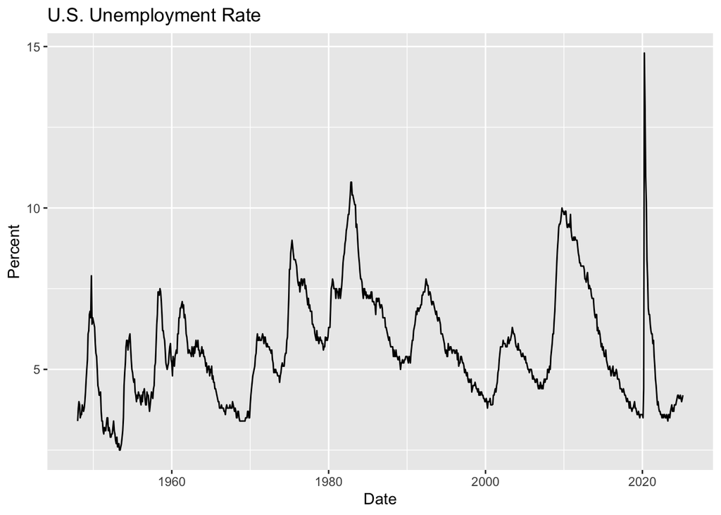

```r
# Time series plots
phillips_data %>%
  ggplot(aes(x = Date, y = Unemployment)) +
  geom_line() +
  labs(title = "U.S. Unemployment Rate", x = "Date", y = "Percent")
```

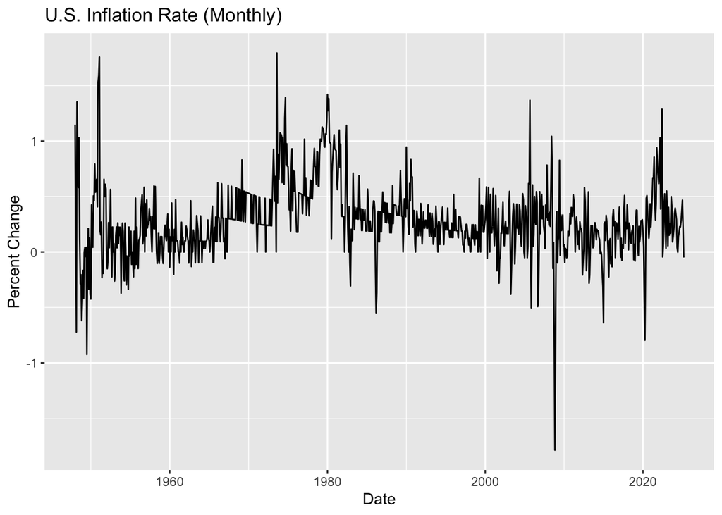

```r
phillips_data %>%
  ggplot(aes(x = Date, y = Inflation)) +
  geom_line() +
  labs(title = "U.S. Inflation Rate (Monthly)", x = "Date", y = "Percent Change")
```

**Explanation:**  
Summary statistics and visual plots allow us to spot trends, volatility, and any periods of unusual behavior in the time series.

# 7 Stationarity Testing

Stationarity is critical for valid statistical inference.

## 7.1 5. Test for Stationarity (Augmented Dickey-Fuller Tests)

```r
# ADF Tests
adf.test(phillips_data$Unemployment)
```

```
    Augmented Dickey-Fuller Test

data:  phillips_data$Unemployment
Dickey-Fuller = -3.9614, Lag order = 9, p-value = 0.01093
alternative hypothesis: stationary
```

```r
adf.test(phillips_data$Inflation)
```

```
    Augmented Dickey-Fuller Test

data:  phillips_data$Inflation
Dickey-Fuller = -4.2188, Lag order = 9, p-value = 0.01
alternative hypothesis: stationary
```

**Explanation:**  
The ADF test helps determine if the series are stationary or if they contain unit roots, indicating a need for differencing.

## 7.2 6. Transform the Data if Necessary

```r
# First difference unemployment if needed
phillips_data <- phillips_data %>%
  mutate(
    d_Unemployment = c(NA, diff(Unemployment))
  )

# Rerun ADF on differenced series
adf.test(na.omit(phillips_data$d_Unemployment))
```

```
    Augmented Dickey-Fuller Test

data:  na.omit(phillips_data$d_Unemployment)
Dickey-Fuller = -9.7509, Lag order = 9, p-value = 0.01
alternative hypothesis: stationary
```

**Explanation:**  
Differencing is applied if a series is non-stationary. Stationary series have constant mean and variance over time.

# 8 Model Estimation

## 8.1 7. Estimate a Basic Phillips Curve

```r
model1 <- lm(Inflation ~ d_Unemployment, data = phillips_data)
summary(model1)
```

```
Call:
lm(formula = Inflation ~ d_Unemployment, data = phillips_data)

Residuals:
     Min       1Q   Median       3Q      Max
-2.04016 -0.18154 -0.03435  0.14481  1.51265

Coefficients:
               Estimate Std. Error t value Pr(>|t|)
(Intercept)     0.28112    0.01077  26.097  < 2e-16 ***
d_Unemployment -0.09124    0.02590  -3.523 0.000448 ***
---
Signif. codes:  0 '***' 0.001 '**' 0.01 '*' 0.05 '.' 0.1 ' ' 1

Residual standard error: 0.3278 on 924 degrees of freedom
  (1 observation deleted due to missingness)
Multiple R-squared:  0.01325,   Adjusted R-squared:  0.01218
F-statistic: 12.41 on 1 and 924 DF,  p-value: 0.0004481
```

**Explanation:**  
We estimate a basic Phillips Curve model where inflation is regressed on unemployment.

# 9 Diagnostic Testing

Checking for model validity is crucial before moving to interpretation or policy recommendations.

## 9.1 8. Test for Serial Correlation (Breusch-Godfrey Test)

```r
bgtest(model1, order = 12)
```

```
    Breusch-Godfrey test for serial correlation of order up to 12

data:  model1
LM test = 396.8, df = 12, p-value < 2.2e-16
```

**Explanation:**  
Serial correlation in the residuals can undermine regression validity by inflating the goodness-of-fit and leading to biased standard errors. The Breusch-Godfrey test checks for autocorrelation up to 12 lags, which covers one year of monthly data. A significant p-value (typically p < 0.05) indicates that serial correlation is present and that the model may need modification.

**Interpretation Task:**  
- Examine the p-value from the Breusch-Godfrey test. - If the p-value is **small** (below 0.05), conclude that serial correlation exists, meaning residuals are not independent and the model needs adjustment (e.g., by adding a lagged variable). - If the p-value is **large** (above 0.05), conclude that there is no evidence of serial correlation, and proceed with the model. - In either case, briefly explain your conclusion about the presence or absence of residual autocorrelation.

# 10 Model Improvement

After diagnosing issues such as serial correlation, it is important to modify the model to improve its validity.

## 10.1 9. Add Lagged Inflation to the Model

```r
# Add lagged inflation
phillips_data <- phillips_data %>%
  mutate(
    Inflation_Lag = lag(Inflation)
  )

# Remove missing values
phillips_data2 <- na.omit(phillips_data)

# New model
model2 <- lm(Inflation ~ d_Unemployment + Inflation_Lag, data = phillips_data2)
summary(model2)
```

```
Call:
lm(formula = Inflation ~ d_Unemployment + Inflation_Lag, data = phillips_data2)

Residuals:
     Min       1Q   Median       3Q      Max
-1.37383 -0.14260 -0.01179  0.13125  1.67802

Coefficients:
               Estimate Std. Error t value Pr(>|t|)
(Intercept)     0.11575    0.01143  10.123  < 2e-16 ***
d_Unemployment -0.07524    0.02092  -3.597 0.000339 ***
Inflation_Lag   0.58567    0.02631  22.265  < 2e-16 ***
---
Signif. codes:  0 '***' 0.001 '**' 0.01 '*' 0.05 '.' 0.1 ' ' 1

Residual standard error: 0.2645 on 923 degrees of freedom
Multiple R-squared:  0.358, Adjusted R-squared:  0.3566
F-statistic: 257.4 on 2 and 923 DF,  p-value: < 2.2e-16
```

**Explanation:**  
Including a lagged value of inflation (the dependent variable) captures the persistence of inflation over time, which is common in macroeconomic data.When a dependent variable is persistent, shocks or movements today can affect future outcomes. If this dynamic is ignored, residuals may show serial correlation because the model is missing an important source of explanatory power. Adding a lagged dependent variable often helps correct for serial correlation because it allows the model to explicitly account for the dynamic structure of the data.

# 11 Interpretation

## 11.1 10. Interpretation Questions

Answer the following questions: - Was serial correlation present initially? - How did adding lagged inflation affect the model? - Interpret the coefficient on lagged inflation. - Discuss implications for policymakers.

# 12 Bonus: Structural Breaks with Bai-Perron Method

Economic relationships are often subject to change over time due to major events such as financial crises, technological innovations, or shifts in public policy. These changes can cause structural breaks in the relationship between key variables, such as unemployment and inflation. The Bai-Perron method provides a formal statistical test for detecting multiple unknown structural breaks within a regression model. Rather than requiring the researcher to specify when changes might have occurred, the method searches for breakpoints systematically. It then divides the data into distinct regimes, allowing the underlying relationship, such as the Phillips Curve, to vary across different periods.

## 12.1 11. Apply Bai-Perron Test

```r
# Run Bai-Perron
breakpoints_model2 <- breakpoints(Inflation ~ d_Unemployment + Inflation_Lag, data = phillips_data2)
```

**Explanation:**  
We identify when major shifts in the inflation-unemployment relationship occurred.

## 12.2 12. Determine the Number of Breaks

This uses the BIC to determin the number of breakpoints.

```r
# Extract break dates
break_dates <- phillips_data2$Date[breakpoints_model2$breakpoints]
break_dates
```

```
[1] "1967-05-01" "1982-06-01"
```

**Explanation:**  
The best number of breaks minimizes the BIC criterion. The dates are when the relationship mostlikly changes.

## 12.3 Interpretation Questions

- How many breaks were found?
- What does this suggest about the stability of the Phillips Curve?

# 13 Optional Extension: Re-Estimating the Phillips Curve Before and After Breakpoints

## 13.1 13. Split and Re-Estimate

```r
# Assume a break in 2010 for illustration

phillips_pre <- phillips_data2 %>%
  filter(Date >= as.Date("1967-05-01") & Date < as.Date("1982-06-01"))
phillips_post <- phillips_data2 %>% filter(Date > as.Date("1982-06-01"))

# Pre-break model
model_pre <- lm(Inflation ~ Unemployment + Inflation_Lag, data = phillips_pre)
summary(model_pre)
```

```
Call:
lm(formula = Inflation ~ Unemployment + Inflation_Lag, data = phillips_pre)

Residuals:
     Min       1Q   Median       3Q      Max
-0.82372 -0.14902 -0.02077  0.16893  1.54889

Coefficients:
              Estimate Std. Error t value Pr(>|t|)
(Intercept)   0.204928   0.081597   2.511   0.0129 *
Unemployment  0.008323   0.012533   0.664   0.5075
Inflation_Lag 0.569921   0.061836   9.217   <2e-16 ***
---
Signif. codes:  0 '***' 0.001 '**' 0.01 '*' 0.05 '.' 0.1 ' ' 1

Residual standard error: 0.2642 on 178 degrees of freedom
Multiple R-squared:  0.3314,    Adjusted R-squared:  0.3239
F-statistic: 44.12 on 2 and 178 DF,  p-value: 2.744e-16
```

```r
# Post-break model
model_post <- lm(Inflation ~ Unemployment + Inflation_Lag, data = phillips_post)
summary(model_post)
```

```
Call:
lm(formula = Inflation ~ Unemployment + Inflation_Lag, data = phillips_post)

Residuals:
     Min       1Q   Median       3Q      Max
-1.51233 -0.10963 -0.00169  0.11540  0.95537

Coefficients:
               Estimate Std. Error t value Pr(>|t|)
(Intercept)    0.169309   0.037982   4.458 1.02e-05 ***
Unemployment  -0.007360   0.005754  -1.279    0.201
Inflation_Lag  0.455484   0.039021  11.673  < 2e-16 ***
---
Signif. codes:  0 '***' 0.001 '**' 0.01 '*' 0.05 '.' 0.1 ' ' 1

Residual standard error: 0.233 on 510 degrees of freedom
Multiple R-squared:  0.2203,    Adjusted R-squared:  0.2172
F-statistic: 72.05 on 2 and 510 DF,  p-value: < 2.2e-16
```

## 13.2 Interpretation Questions

- How did the coefficients differ before and after the break?
- Did inflation persistence change?
- How should policymakers adjust based on these findings?

# 14 Final Deliverables

Submit:

- Fully annotated R code
- Output summaries
- ADF, Breusch-Godfrey, and Bai-Perron test results
- Plots
- Written interpretation answers

# 15 Helpful Reminders

- Always check stationarity before modeling.
- Always diagnose residuals for serial correlation.
- Always question whether relationships are stable over time.